# Titanic Disaster Report

## Introduction

The sinking of the RMS Titanic is one of the most infamous shipwrecks in history. On April 15, 1912, during her maiden voyage, the Titanic sank after colliding with an iceberg, killing 1502 out of 2224 passengers and crew. This sensational tragedy shocked the international community and led to better safety regulations for ships. 891 of passengers including 577 males and 314 females were selected to be studied. In the data sheet, age, fare, passenger class and name are listed. In this report, we are going to find what is the average age for each group? How many people for each group? Which group of group are more likely to survive than others?

## How Many People for Each Group?

Among the selected 891 passengers, 577 were males and 314 were females. The secio-economic status were divived into upper level, middle level and lower level which included 216, 184 and 491 people. After the accident, 342 people were survived including 233 females and 109 males. Among the survived passengers, 136 were from upper level, 87 were from middle level and 119 were from lower level. In addition, among the survived females, 91, 70 and 72 passengers were from upper, middle and lower level respectively. By contract, for survived male passengers, 45, 17, 47 were from upper, middle and lower level respectively.

## Which group of group are more likely to survive than others?

In addition, based on pie chart, 68.1% of survivor were female and only 31.9% were male.

## Limitation

Based on data sheet, it can be found that 177 passengers' age were missing. Therefore, the the majority survived passenger may be not under 40 years old.

## Conclusion

Also, the upper level passenger were more likely to survive because they spend more on fare. Moreover, the correation was 0.25 which means they were related. Higher fare may mean a safer cabin and more safety equipment. Thus, passengers who spent more on fare had a higher chance to survive.

```python
%pylab inline
import numpy as np
import pandas as pd
import matplotlib.pyplot as plt
import seaborn as sns
```

```python
#Loading data into a Dataframe
titanic_data = pd.read_csv('titanic_data.csv')
```

```python
#Show first 5 rows of dataframe
titanic_data.head()
```

|  | PassengerId | Survived | Pclass | Name | Sex | Age | SibSp | Parch | Ticket | Fare | Cabin | Embarked |
| --- | --- | --- | --- | --- | --- | --- | --- | --- | --- | --- | --- | --- |
| 0 | 1 | 0 | 3 | Braund, Mr. Owen Harris | male | 22.0 | 1 | 0 | A/5 21171 | 7.2500 | NaN | S |
| 1 | 2 | 1 | 1 | Cumings, Mrs. John Bradley (Florence Briggs Th... | female | 38.0 | 1 | 0 | PC 17599 | 71.2833 | C85 | C |
| 2 | 3 | 1 | 3 | Heikkinen, Miss. Laina | female | 26.0 | 0 | 0 | STON/O2. 3101282 | 7.9250 | NaN | S |
| 3 | 4 | 1 | 1 | Futrelle, Mrs. Jacques Heath (Lily May Peel) | female | 35.0 | 1 | 0 | 113803 | 53.1000 | C123 | S |
| 4 | 5 | 0 | 3 | Allen, Mr. William Henry | male | 35.0 | 0 | 0 | 373450 | 8.0500 | NaN | S |

```python
#Average age of all the passengers
titanic_data['Age'].mean()
```

```
29.69911764705882
```

```python
#Divide into two groups(male and female) to investigate data
titanic_data.groupby('Sex').describe()['Age']
```

```
Sex
female  count    261.000000
        mean      27.915709
        std       14.110146
        min        0.750000
        25%       18.000000
        50%       27.000000
        75%       37.000000
        max       63.000000
male    count    453.000000
        mean      30.726645
        std       14.678201
        min        0.420000
        25%       21.000000
        50%       29.000000
        75%       39.000000
        max       80.000000
Name: Age, dtype: float64
```

```python
titanic_data.groupby(['Survived'])[['PassengerId']].count()
```

| Survived | PassengerId |
| --- | --- |
| 0 | 549 |
| 1 | 342 |

```python
print ("Number of survived people:", 342)
print ("Number of died people:", 549)
```

```
Number of survived people: 342
Number of died people: 549
```

```python
#Among the survived passenger, what't the number of female and male passenger?
titanic_data.groupby(['Sex']).sum()['Survived']
```

```
Sex
female    233
male      109
Name: Survived, dtype: int64
```

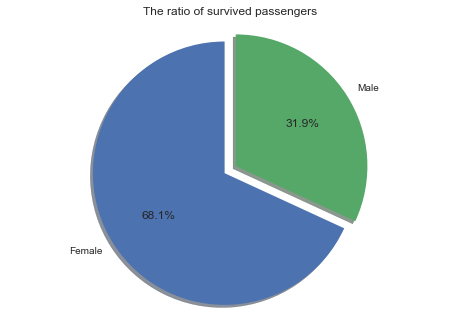

```python
#Pie chart for the ratio: male to female
num_of_survived_female = 233
num_of_survived_male = 109
num_of_survived =342
labels = 'Female', 'Male'
sizes = [num_of_survived_female / num_of_survived, num_of_survived_male / num_of_survived]
explode = (0.1, 0)
fig1, ax1 = plt.subplots()
ax1.pie(sizes, explode=explode, labels=labels, autopct='%1.1f%%',
        shadow=True, startangle=90)
ax1.axis('equal')
plt.title('The ratio of survived passengers')
```

```python
num_of_female = 261
num_of_male = 453

print ('The survival rate for female is', num_of_survived_female / num_of_female)
print ('The survival rate for male is', num_of_survived_male / num_of_male)
```

```
The survival rate for female is 0.89272030651341
The survival rate for male is 0.24061810154525387
```

|  | Age |
| --- | --- |
| count | 714.000000 |
| mean | 29.699118 |
| std | 14.526497 |
| min | 0.420000 |
| 25% | 20.125000 |
| 50% | 28.000000 |
| 75% | 38.000000 |
| max | 80.000000 |

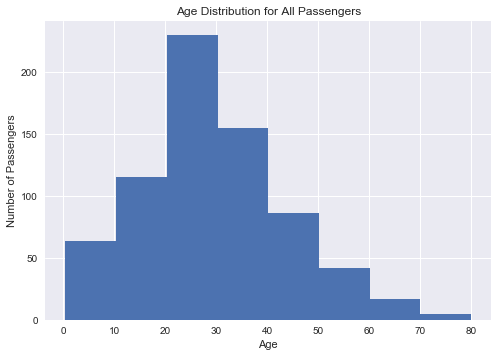

```python
ax = titanic_data['Age'].hist(bins=8)
ax.set_ylabel('Number of Passengers')
ax.set_xlabel('Age')
ax.set_title('Age Distribution for All Passengers')
pd.DataFrame(titanic_data['Age'].describe())
```

|  | Age |
| --- | --- |
| count | 290.000000 |
| mean | 28.343690 |
| std | 14.950952 |
| min | 0.420000 |
| 25% | 19.000000 |
| 50% | 28.000000 |
| 75% | 36.000000 |
| max | 80.000000 |

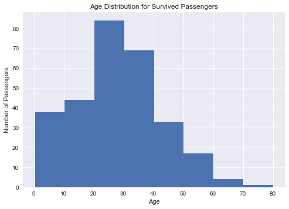

```python
df_age = titanic_data.groupby('Survived').get_group(1)
np.seterr(invalid='ignore')

ax = df_age['Age'].hist(bins=8)
ax.set_ylabel('Number of Passengers')
ax.set_xlabel('Age')
ax.set_title('Age Distribution for Survived Passengers')
pd.DataFrame(df_age['Age'].describe())
```

```python
# The average age by sex and survived
titanic_data.groupby(['Survived','Sex']).mean()['Age']
```

```
Survived  Sex
0         female    25.046875
          male      31.618056
1         female    28.847716
          male      27.276022
Name: Age, dtype: float64
```

```python
#Check the average ticket fare for survived and died passengers

fare_survived = titanic_data.groupby('Survived').get_group(1)['Fare'].mean()

fare_dead = titanic_data.groupby('Survived').get_group(0)['Fare'].mean()

print ('The averager fare for survived passengers is:', fare_survived)
print ('The averager fare for died passengers is:', fare_dead)
```

```
The averager fare for survived passengers is: 48.39540760233917
The averager fare for died passengers is: 22.117886885245877
```

| Survived |  | Fare |
| --- | --- | --- |
| 0 | mean | 22.117887 |
|  | std | 31.388207 |
| 1 | mean | 48.395408 |
|  | std | 66.596998 |

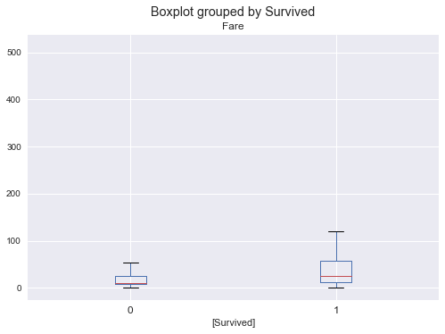

```python
titanic_data.boxplot(column=['Fare'],by = ['Survived'])
pd.DataFrame(titanic_data.groupby(['Survived'])['Fare'].describe().loc[:,['mean','std']])
```

```python
# The average fare by survived and sex
titanic_data.groupby(['Survived','Sex']).mean()['Fare']
```

```
Survived  Sex
0         female    23.024385
          male      21.960993
1         female    51.938573
          male      40.821484
Name: Fare, dtype: float64
```

| Sex | Pclass | Survived |
| --- | --- | --- |
| female | 1 | 91 |
|  | 2 | 70 |
|  | 3 | 72 |
| male | 1 | 45 |
|  | 2 | 17 |
|  | 3 | 47 |

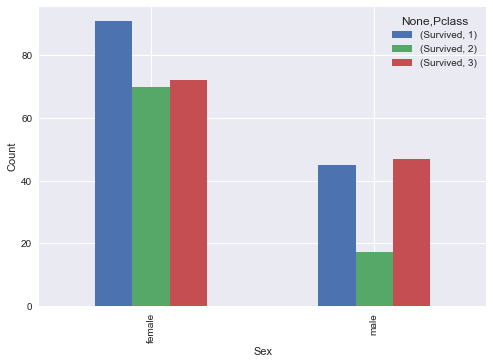

```python
titanic_data.groupby(['Sex','Pclass'])[['Survived']].sum().unstack().plot(kind='bar').set_ylabel('Count')
titanic_data.groupby(['Sex','Pclass'])[['Survived']].sum()
```

```python
# Pearson's r
def correlation(x, y):
    std_x = (x - x.mean()) / x.std(ddof=0)
    std_y = (y - y.mean()) / y.std(ddof=0)

    return (std_x * std_y).mean()
```

```python
# Correlation Between Fare and Survived
numpy.corrcoef(titanic_data['Survived'], titanic_data['Fare'])
```

```
array([[ 1.        ,  0.25730652],
       [ 0.25730652,  1.        ]])
```

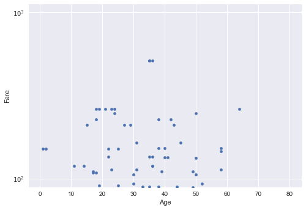

```python
titanic_data.plot(kind = 'scatter', x='Age', y = 'Fare').set_yscale('log')
```

```python
titanic_data.groupby('Pclass')[['PassengerId']].count()
```

| Pclass | PassengerId |
| --- | --- |
| 1 | 216 |
| 2 | 184 |
| 3 | 491 |

216 passengers are from upper level, 184 are middle level and 491 are lower level

```python
titanic_data.groupby(['Survived','Pclass'])[['PassengerId']].count()
```

| Survived | Pclass | PassengerId |
| --- | --- | --- |
| 0 | 1 | 80 |
|  | 2 | 97 |
|  | 3 | 372 |
| 1 | 1 | 136 |
|  | 2 | 87 |
|  | 3 | 119 |

```python
print ('Number of survived upper level:', 136)
print ('Number of survived middle level:', 87)
print ('Number of survived lower level:', 119)
```

```
Number of survived upper level: 136
Number of survived middle level: 87
Number of survived lower level: 119
```

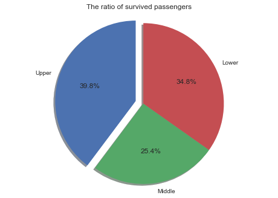

```python
#Pie chart for the ratio

num_of_survived_upper = 136
num_of_survived_middle = 87
num_of_survived_lower = 119
num_of_survived = 342

labels = 'Upper', 'Middle', 'Lower'
sizes = [num_of_survived_upper / num_of_survived, num_of_survived_middle / num_of_survived, num_of_survived_lower / num_of_survived]
explode = (0.1, 0, 0)
fig1, ax1 = plt.subplots()
ax1.pie(sizes, explode=explode, labels=labels, autopct='%1.1f%%',
        shadow=True, startangle=90)
ax1.axis('equal')
plt.title('The ratio of survived passengers')
```

```python
num_of_upper = 216
num_of_middle = 184
num_of_lower = 491
print ('The survive rates of upper, middle and lower are:', num_of_survived_upper / num_of_upper,
       num_of_survived_middle / num_of_middle, num_of_survived_lower / num_of_lower)
```

```
The survive rates of upper, middle and lower are: 0.6296296296296297 0.47282608695652173 0.24236252545824846
```

```python
titanic_data.groupby('Pclass').mean()['Fare']
```

```
Pclass
1    84.154687
2    20.662183
3    13.675550
Name: Fare, dtype: float64
```